# Actividad 10

- Jorge Emiliano Pomar
- A01709338
- 21 de febrero de 2025

## Ejercicio 1

Diseña la función lista_compras () que cree un diccionario que simule una lista de compras. La función deberá preguntar el artículo y su precio y añadir el par de datos al diccionario, hasta que el usuario decida terminar. Cada vez que se añadan datos, debe imprimirse el contenido del diccionario. La función deberá regresar el diccionario con los datos de los artículos comprados. En el main se debe imprimir el diccionario final.

```python
def lista_compras():
    articulos = {}
    continua = "s"
    while continua.lower() == "s" or continua.lower() == "si":
        nombre = input("Ingresa el nombre del articulo: ")
        precio = float(input("Ingresa el precio del articulo: "))
        articulos[nombre] = precio
        print(articulos)
        continua = input("\n Deseas agregar mas informacion? (s/n) ")
    return articulos


def main():
    datos = lista_compras()
    print(datos)


main()
```

```
{'Jabón': 15.0}
{'Jabón': 15.0, 'Escoba': 90.0}
{'Jabón': 15.0, 'Escoba': 90.0, 'Queso': 50.0}
{'Jabón': 15.0, 'Escoba': 90.0, 'Queso': 50.0}
```

## Ejercicio 2

Diseña la función imprime_compras (diccionario) que recibe el diccionario creado en la función lista_compras() y muestra en pantalla la lista de las compras y el costo total, con el siguiente formato:

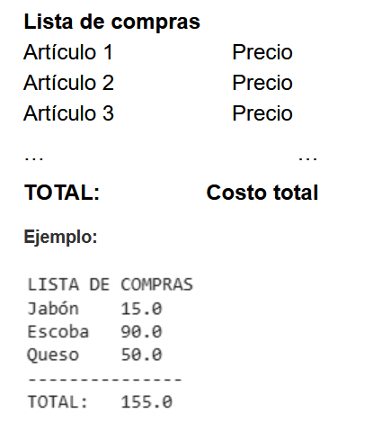

```python
def imprime_compras(diccionario):
    print("\nLISTA DE COMPRAS")
    total = 0
    cont = 0
    for key in diccionario:
        print(key, " ", diccionario[key])
        total += diccionario[key]
        cont += 1
    print("--------------------")
    print("TOTAL: ", total)


def main():
    datos = lista_compras()
    imprime_compras(datos)


main()
```

```
{'Jabon': 15.0}
{'Jabon': 15.0, 'Jamon': 300.0}
{'Jabon': 15.0, 'Jamon': 300.0, 'Escoba': 75.0}
{'Jabon': 15.0, 'Jamon': 300.0, 'Escoba': 75.0, 'Queso': 153.0}
{'Jabon': 15.0, 'Jamon': 300.0, 'Escoba': 75.0, 'Queso': 153.0, 'Pan': 64.0}

LISTA DE COMPRAS
Jabon   15.0
Jamon   300.0
Escoba   75.0
Queso   153.0
Pan   64.0
--------------------
TOTAL:  607.0
```

## Ejercicio 3

Diseñe la función promedio que reciba una tupla como parámetro de entrada y con un ciclo for regrese el valor promedio de los elementos almacenados en la tupla. NOTA: Utiliza el ciclo for y un acumulador. Diseñe la función main: Almacene una tupla con los valores: 1, 2, 2, 2, 3, 3, 3, 4 y llámela t. Imprima el tamaño de la tupla con la función len. Usando la función count, imprima el conteo de elementos igual a 2 y de elementos igual a 3. Llama a la función promedio con la tupla creada t e imprime el resultado de la función.

```python
def promedio(tupla):
    suma = 0
    for i in tupla:
        suma += i
    return suma / len(tupla)


def main():
    t = (1, 2, 2, 2, 3, 3, 3, 4)
    print("Tamaño de la tupla: ",len(t))
    print("Elementos igual a 2: ", t.count(2))
    print("Elementos igual a 3: ", t.count(3))
    prom = promedio(t)
    print("Promedio: ", prom)


main()
```

```
Tamaño de la tupla:  8
Elementos igual a 2:  3
Elementos igual a 3:  3
Promedio:  2.5
```